# Proyecto

SRP132992 ## Obtencion de la lobreria y los proyectos disponibles

```r
library("recount3")
projects <- available_projects()
```

```
## 2021-02-26 09:18:18 caching file sra.recount_project.MD.gz.
```

```
## 2021-02-26 09:18:20 caching file gtex.recount_project.MD.gz.
```

```
## 2021-02-26 09:18:21 caching file tcga.recount_project.MD.gz.
```

## Obtencion del proyecto SRP132992

Informacion de 50 muestras del articulo **“Epigenetic dysregulation of enhancers in neurons is associated with Alzheimer’s disease pathology and cognitive symptoms (RNA-Seq)”**

```r
#Descarga del proyecto

proj_info <- subset(
    projects,
    project == "SRP132992" & project_type == "data_sources"
)

rse <- create_rse(proj_info)
```

```
## 2021-02-26 09:18:32 downloading and reading the metadata.
```

```
## 2021-02-26 09:18:35 caching file sra.sra.SRP132992.MD.gz.
```

```
## 2021-02-26 09:18:36 caching file sra.recount_project.SRP132992.MD.gz.
```

```
## 2021-02-26 09:18:38 caching file sra.recount_qc.SRP132992.MD.gz.
```

```
## 2021-02-26 09:18:39 caching file sra.recount_seq_qc.SRP132992.MD.gz.
```

```
## 2021-02-26 09:18:41 caching file sra.recount_pred.SRP132992.MD.gz.
```

```
## 2021-02-26 09:18:43 downloading and reading the feature information.
```

```
## 2021-02-26 09:18:43 caching file human.gene_sums.G026.gtf.gz.
```

```
## 2021-02-26 09:18:45 downloading and reading the counts: 50 samples across 63856 features.
```

```
## 2021-02-26 09:18:47 caching file sra.gene_sums.SRP132992.G026.gz.
```

```
## 2021-02-26 09:18:49 construcing the RangedSummarizedExperiment (rse) object.
```

#Exploracion de los datos obtenidos

```r
print("rse")
```

```
## [1] "rse"
```

```r
rse
```

```
## class: RangedSummarizedExperiment
## dim: 63856 50
## metadata(8): time_created recount3_version ... annotation recount3_url
## assays(1): raw_counts
## rownames(63856): ENSG00000278704.1 ENSG00000277400.1 ...
##   ENSG00000182484.15_PAR_Y ENSG00000227159.8_PAR_Y
## rowData names(10): source type ... havana_gene tag
## colnames(50): SRR6742933 SRR6742934 ... SRR6742978 SRR6742979
## colData names(175): rail_id external_id ...
##   recount_pred.curated.cell_line BigWigURL
```

```r
assay(rse, "counts") <- compute_read_counts(rse)
print("Atributos")
```

```
## [1] "Atributos"
```

```r
rse$sra.sample_attributes[1:3]
```

```
## [1] "age;;88|braak stage;;5|brain bank;;King's College|pmi;;41|replicate;;Biological sample|Sex;;male|source_name;;Brain prefrontal cortex"
## [2] "age;;88|braak stage;;5|brain bank;;King's College|pmi;;41|replicate;;Biological sample|Sex;;male|source_name;;Brain prefrontal cortex"
## [3] "age;;72|braak stage;;2|brain bank;;King's College|pmi;;51|replicate;;Biological sample|Sex;;female|source_name;;Brain prefrontal cortex"
```

```
Se analizan 63856 genes de las 50 muestras y los atributos de las muestras parecen ser los mismos.
```

```r
rse <- expand_sra_attributes(rse)
colData(rse)[
    ,
    grepl("^sra_attribute", colnames(colData(rse)))
]
```

```
## DataFrame with 50 rows and 7 columns
##            sra_attribute.age sra_attribute.braak_stage sra_attribute.brain_bank
##                  <character>               <character>              <character>
## SRR6742933                88                         5           King's College
## SRR6742934                88                         5           King's College
## SRR6742935                72                         2           King's College
## SRR6742936                72                         2           King's College
## SRR6742937                85                         6           King's College
## ...                      ...                       ...                      ...
## SRR6742975                85                         6           King's College
## SRR6742976                85                         6           King's College
## SRR6742977                80                         2           King's College
## SRR6742978                80                         2           King's College
## SRR6742979                86                         3               Manchester
##            sra_attribute.pmi sra_attribute.replicate sra_attribute.Sex
##                  <character>             <character>       <character>
## SRR6742933                41       Biological sample              male
## SRR6742934                41       Biological sample              male
## SRR6742935                51       Biological sample            female
## SRR6742936                51       Biological sample            female
## SRR6742937              23.5       Biological sample              male
## ...                      ...                     ...               ...
## SRR6742975                29       Biological sample            female
## SRR6742976                29       Biological sample            female
## SRR6742977                54       Biological sample              male
## SRR6742978                54       Biological sample              male
## SRR6742979             35.15       Biological sample            female
##            sra_attribute.source_name
##                          <character>
## SRR6742933    Brain prefrontal cor..
## SRR6742934    Brain prefrontal cor..
## SRR6742935    Brain prefrontal cor..
## SRR6742936    Brain prefrontal cor..
## SRR6742937    Brain prefrontal cor..
## ...                              ...
## SRR6742975    Brain prefrontal cor..
## SRR6742976    Brain prefrontal cor..
## SRR6742977    Brain prefrontal cor..
## SRR6742978    Brain prefrontal cor..
## SRR6742979    Brain prefrontal cor..
```

Se realiza un reasignacion a los atributos que lo necesiten

```r
rse$sra_attribute.age <- as.numeric(rse$sra_attribute.age)
rse$sra_attribute.braak_stage<- as.numeric(rse$sra_attribute.braak_stage)
rse$sra_attribute.pmi<-as.numeric(rse$sra_attribute.pmi)
rse$sra_attribute.Sex<- factor(rse$sra_attribute.Sex)
```

```r
summary(as.data.frame(colData(rse)[
    ,
    grepl("^sra_attribute.[age|braak_stage|brain_bank|pmi|Sex]", colnames(colData(rse)))
]))
```

```
##  sra_attribute.age sra_attribute.braak_stage sra_attribute.brain_bank
##  Min.   :65.00     Min.   :1.000             Length:50
##  1st Qu.:85.00     1st Qu.:2.000             Class :character
##  Median :88.00     Median :3.000             Mode  :character
##  Mean   :86.12     Mean   :3.476
##  3rd Qu.:91.00     3rd Qu.:4.000
##  Max.   :98.00     Max.   :6.000
##                    NA's   :8
##  sra_attribute.pmi sra_attribute.replicate sra_attribute.Sex
##  Min.   :11.00     Length:50               female:24
##  1st Qu.:28.50     Class :character        male  :26
##  Median :51.00     Mode  :character
##  Mean   :44.73
##  3rd Qu.:58.00
##  Max.   :78.00
##
##  sra_attribute.source_name
##  Length:50
##  Class :character
##  Mode  :character
##
##
##
##
```

Las variables se creearan a partir de la edad de la mediana (88.00)

```r
rse$pre_media <- factor(ifelse(rse$sra_attribute.age <88, "pre_media", "post_media"))
table(rse$pre_media)
```

```
##
## post_media  pre_media
##         26         24
```

### Control de calidad

```r
rse$assigned_gene_prop <- rse$recount_qc.gene_fc_count_all.assigned / rse$recount_qc.gene_fc_count_all.total
summary(rse$assigned_gene_prop)
```

```
##    Min. 1st Qu.  Median    Mean 3rd Qu.    Max.
##  0.3172  0.3324  0.3438  0.3448  0.3508  0.3782
```

```r
rse_unfiltered <- rse
with(colData(rse), tapply(assigned_gene_prop, pre_media , summary))
```

```
## $post_media
##    Min. 1st Qu.  Median    Mean 3rd Qu.    Max.
##  0.3172  0.3273  0.3458  0.3449  0.3571  0.3782
##
## $pre_media
##    Min. 1st Qu.  Median    Mean 3rd Qu.    Max.
##  0.3283  0.3348  0.3432  0.3447  0.3475  0.3706
```

###Eliminamos las muestras de mala calidad

```r
table(rse$assigned_gene_prop < 0.33)
```

```
##
## FALSE  TRUE
##    38    12
```

```r
rse <- rse[, rse$assigned_gene_prop > 0.3]
```

### Niveles de expresión en las muestras

```r
gene_means <- rowMeans(assay(rse, "counts"))
summary(gene_means)
```

```
##      Min.   1st Qu.    Median      Mean   3rd Qu.      Max.
##      0.00      0.06      1.78    132.83     32.44 207351.58
```

Se quitaran los más bajos del primer quantil

```r
rse <- rse[gene_means > 0.1, ]
```

Dimensiones finales:

```r
dim(rse)
```

```
## [1] 46181    50
```

EL numero de muestras no se redujo, pero el numero de genes paso de 63856 a 46181.

## Normalización de los datos

```r
library("edgeR") # BiocManager::install("edgeR", update = FALSE)
dge <- DGEList(
    counts = assay(rse, "counts"),
    genes = rowData(rse)
)
dge <- calcNormFactors(dge)
```

# Expresion diferencial

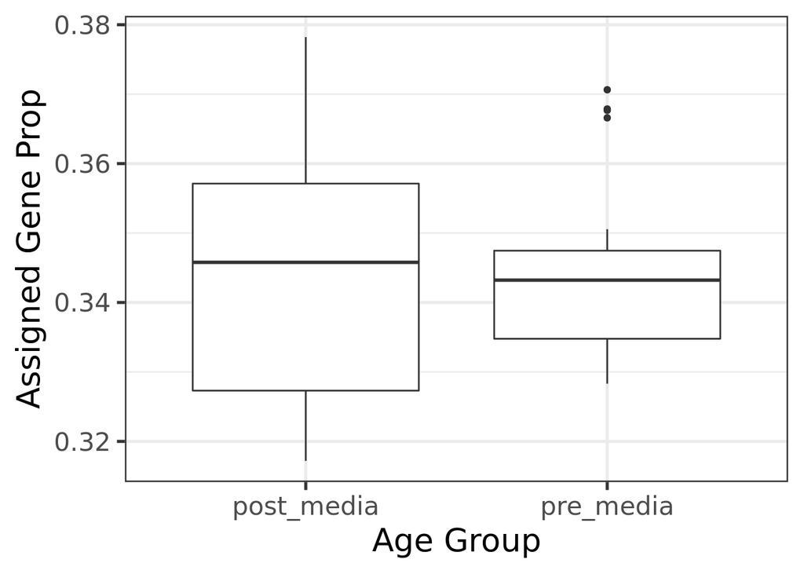

```r
library("ggplot2")
ggplot(as.data.frame(colData(rse)), aes(y = assigned_gene_prop, x = pre_media)) +
    geom_boxplot() +
    theme_bw(base_size = 20) +
    ylab("Assigned Gene Prop") +
    xlab("Age Group")
```

## Modelo

```r
mod <- model.matrix(~ pre_media + sra_attribute.pmi + sra_attribute.Sex + assigned_gene_prop,
    data = colData(rse)
)
colnames(mod)
```

```
## [1] "(Intercept)"           "pre_mediapre_media"    "sra_attribute.pmi"
## [4] "sra_attribute.Sexmale" "assigned_gene_prop"
```

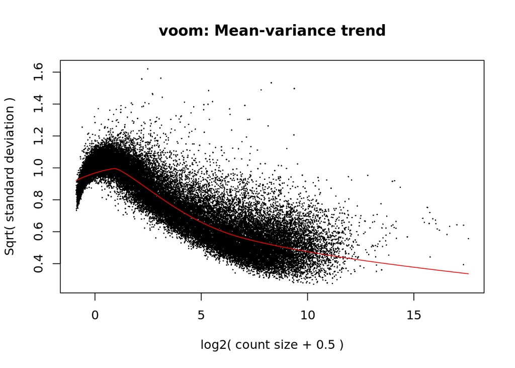

```r
library("limma")
vGene <- voom(dge, mod, plot = TRUE)
```

```r
eb_results <- eBayes(lmFit(vGene))

de_results <- topTable(
    eb_results,
    coef = 2,
    number = nrow(rse),
    sort.by = "none"
)
dim(de_results)
```

```
## [1] 46181    16
```

```r
table(de_results$adj.P.Val < 0.05)
```

```
##
## FALSE  TRUE
## 46168    13
```

```r
indices<-de_results$adj.P.Val < 0.05
indices<-which(indices,arr.ind = TRUE)
```

Con base en nuestro modelo los siguientes genes tienen una expresión diferencial.

```r
de_results$gene_name[indices]
```

```
##  [1] "NR4A1"         "TRPC4"         "KLHL1"         "GCDH"
##  [5] "MAN1A2P1"      "C2orf82"       "ERC2"          "SFRP2"
##  [9] "NSUN2"         "AC009014.3"    "LINC01411"     "RSPO3"
## [13] "RP11-351I21.6"
```

En la siguiente grafica los 13 genes con expresion diferencial estan resaltados

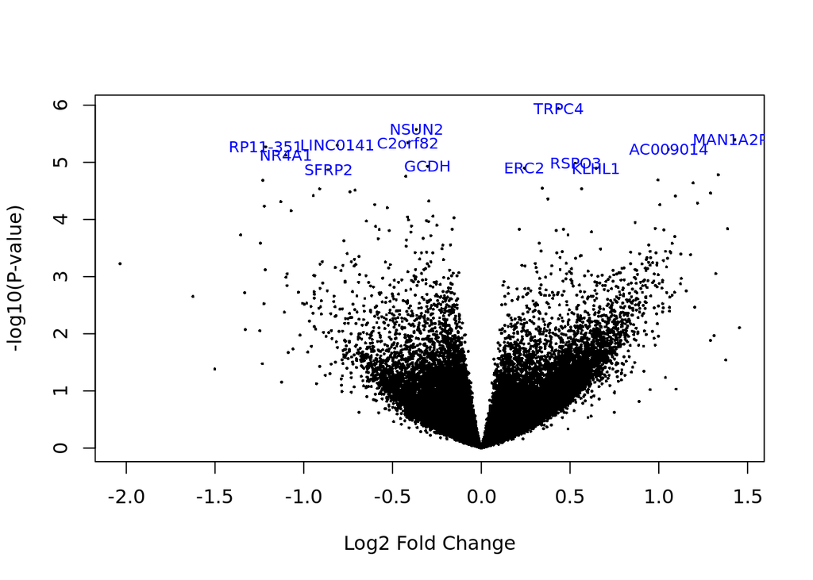

```r
volcanoplot(eb_results, coef = 2, highlight = 13, names = de_results$gene_name)
```

# Visualización

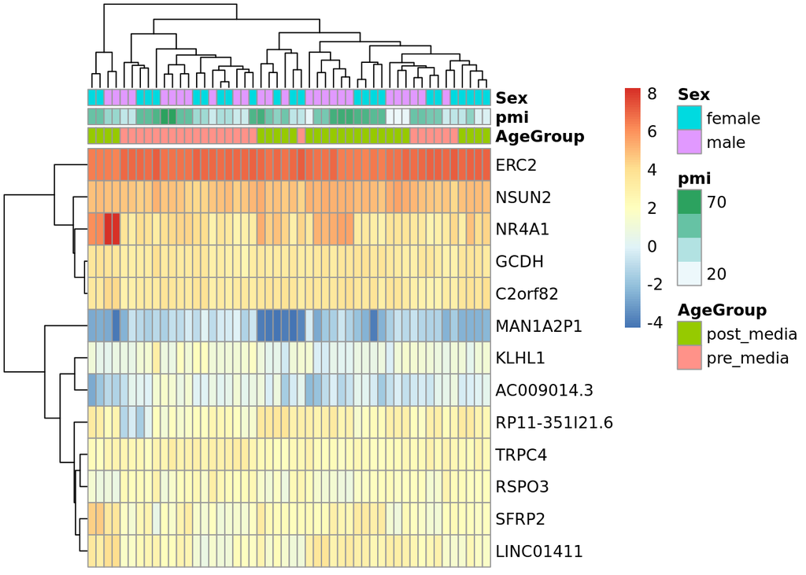

```r
exprs_heatmap <- vGene$E[rank(de_results$adj.P.Val) <= 13, ]
df <- as.data.frame(colData(rse)[, c("pre_media", "sra_attribute.pmi", "sra_attribute.Sex")])
colnames(df) <- c("AgeGroup", "pmi", "Sex")

rownames(exprs_heatmap) <- rowRanges(rse)$gene_name[
    match(rownames(exprs_heatmap), rowRanges(rse)$gene_id)
]

library("pheatmap")
pheatmap(
    exprs_heatmap,
    cluster_rows = TRUE,
    cluster_cols = TRUE,
    show_rownames = TRUE,
    show_colnames = FALSE,
    annotation_col = df
)
```

En el heatmap no parecen haber separaciones claras entre los grupos segun su edad, pmi o sexo, a pesar de que se trata de los genes con expresión diferencial

## Otras graficas

```r
## Para colores
library("RColorBrewer")

## Conviertiendo los grupos de edad a colores
col.group <- df$AgeGroup
levels(col.group) <- brewer.pal(nlevels(col.group), "Set1")
```

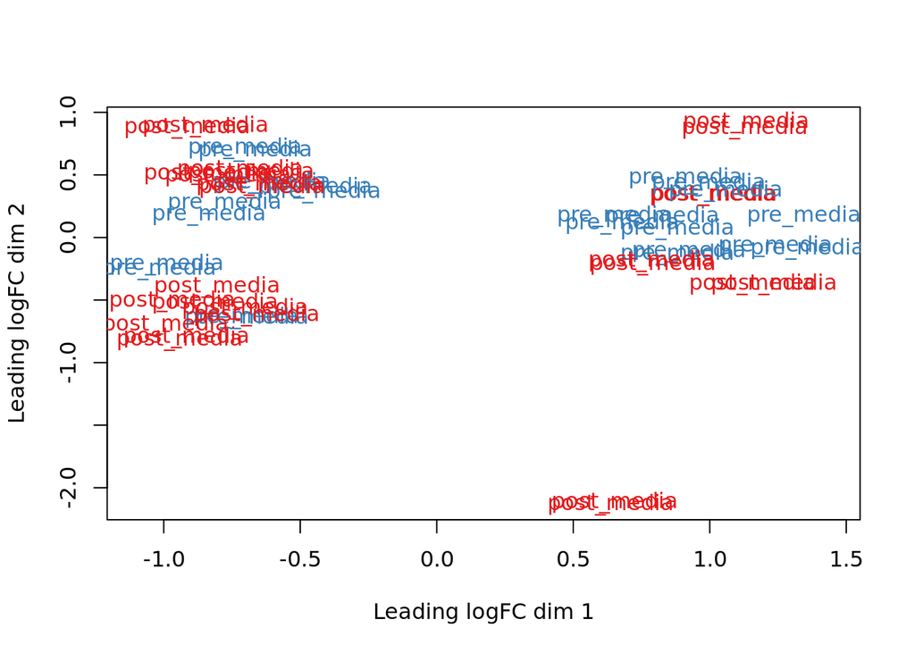

```r
col.group <- as.character(col.group)

## MDS por grupos de edad
plotMDS(vGene$E, labels = df$AgeGroup, col = col.group)
```

La sepación que se observa no se basa en grupos de edad, por lo que debe haber otro factor afectandolo.

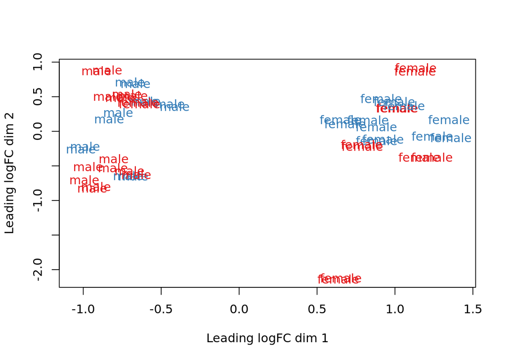

```r
plotMDS(vGene$E, labels = df$Sex, col = col.group)
```

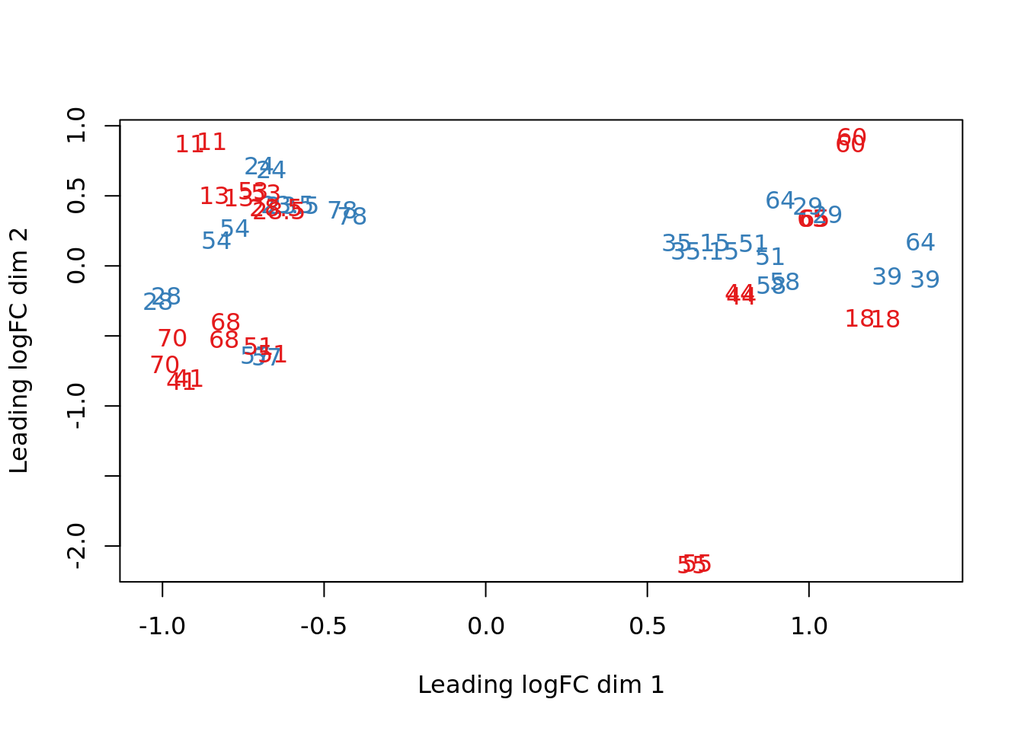

```r
plotMDS(vGene$E, labels = df$pmi, col = col.group)
```

:(

## Variación del modelol

```r
mod <- model.matrix(~ pre_media + sra_attribute.pmi + sra_attribute.Sex + sra_attribute.braak_stage + assigned_gene_prop,
    data = colData(rse)
)
colnames(mod)
```

```
## [1] "(Intercept)"               "pre_mediapre_media"
## [3] "sra_attribute.pmi"         "sra_attribute.Sexmale"
## [5] "sra_attribute.braak_stage" "assigned_gene_prop"
```

```r
eb_results <- eBayes(lmFit(vGene))

de_results <- topTable(
    eb_results,
    coef = 2,
    number = nrow(rse),
    sort.by = "none"
)
table(de_results$adj.P.Val < 0.05)
```

```
##
## FALSE  TRUE
## 46168    13
```

```r
indices<-de_results$adj.P.Val < 0.05
indices<-which(indices,arr.ind = TRUE)
```

```r
de_results$gene_name[indices]
```

```
##  [1] "NR4A1"         "TRPC4"         "KLHL1"         "GCDH"
##  [5] "MAN1A2P1"      "C2orf82"       "ERC2"          "SFRP2"
##  [9] "NSUN2"         "AC009014.3"    "LINC01411"     "RSPO3"
## [13] "RP11-351I21.6"
```

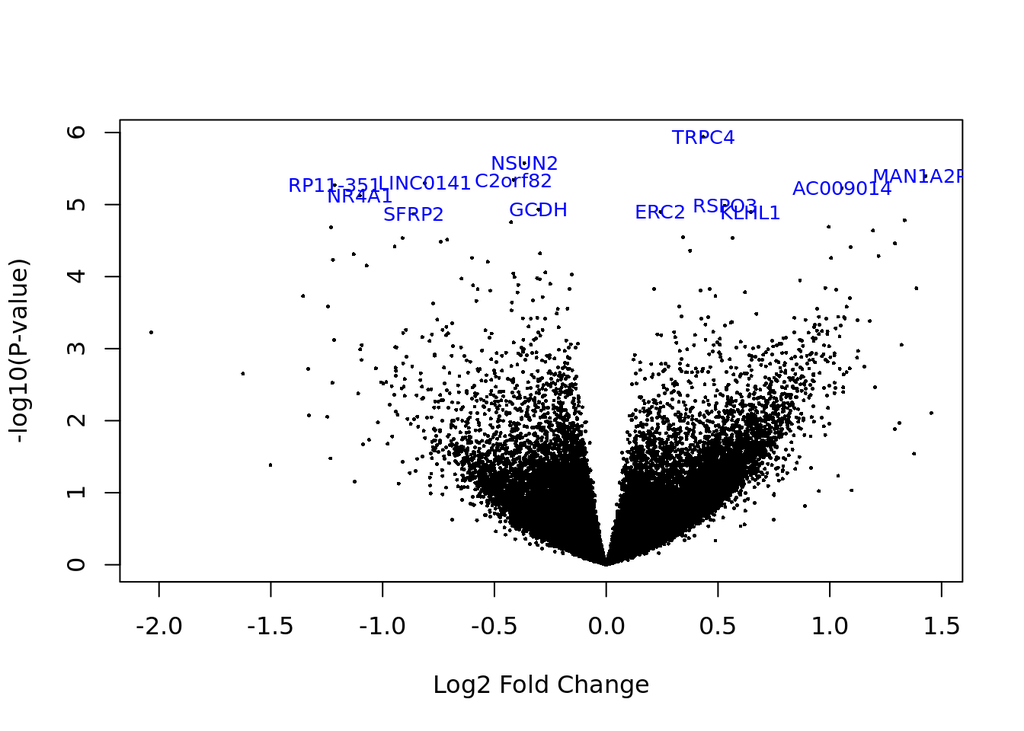

```r
volcanoplot(eb_results, coef = 2, highlight = 13, names = de_results$gene_name)
```

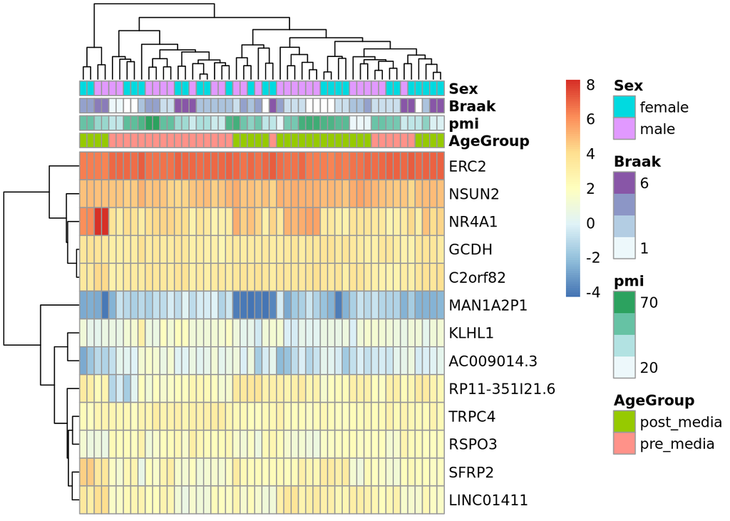

```r
exprs_heatmap <- vGene$E[rank(de_results$adj.P.Val) <= 13, ]
df <- as.data.frame(colData(rse)[, c("pre_media", "sra_attribute.pmi","sra_attribute.braak_stage", "sra_attribute.Sex")])
colnames(df) <- c("AgeGroup", "pmi","Braak", "Sex")

rownames(exprs_heatmap) <- rowRanges(rse)$gene_name[
    match(rownames(exprs_heatmap), rowRanges(rse)$gene_id)
]

library("pheatmap")
pheatmap(
    exprs_heatmap,
    cluster_rows = TRUE,
    cluster_cols = TRUE,
    show_rownames = TRUE,
    show_colnames = FALSE,
    annotation_col = df
)
```

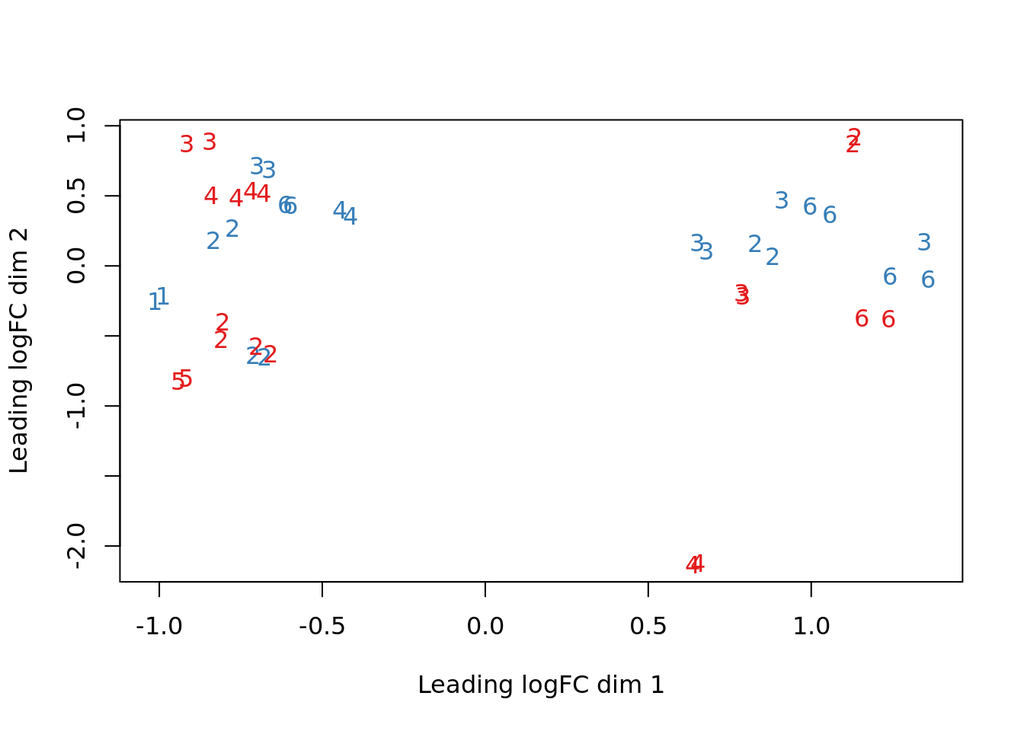

```r
plotMDS(vGene$E, labels = df$Braak, col = col.group)
```

Los resultados nos indica que el braak_stage no es lo que esta separando los resultados.

## Separación de grupos en base al Braak